# Лабораторна робота 4

**Тема:** OpenCV. Просторові методи обробки зображень І. Градаційні перетворення і гістограмні методи (short version)

**Мета:** знайомство з поелементними і гістограмними просторовими методами обробки зображень засобами OpenCV у середовищі Anaconda із застосуванням Jupyter Notebook засобами мови програмування Python.

## Завдання для самостійної роботи

[1. Негатив](https://www.geeksforgeeks.org/python/negative-transformation-of-an-image-using-python-and-opencv/) $s = (L - 1) - r$

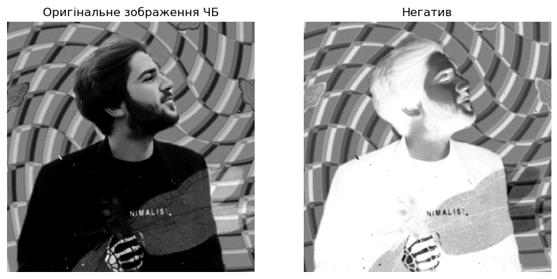

```python
import cv2 as cv
import numpy as np
import matplotlib.pyplot as plt

image_path = 'src/photo.png'
image_gray = cv.imread(image_path, cv.IMREAD_GRAYSCALE)

if image_gray is None:
    print(f"{image_path}")
else:
    image_negative = cv.bitwise_not(image_gray)
    plt.figure(figsize=(10, 5))
    plt.subplot(1, 2, 1)
    plt.imshow(image_gray, cmap='gray')
    plt.title("Оригінальне зображення ЧБ")
    plt.axis('off')

    plt.subplot(1, 2, 2)
    plt.imshow(image_negative, cmap='gray')
    plt.title(r'Негатив')
    plt.axis('off')
    plt.show()
```

[2. Логарифмічні перетворення](https://www.geeksforgeeks.org/python/log-transformation-of-an-image-using-python-and-opencv/) $s = c \cdot \log(1 + r)$

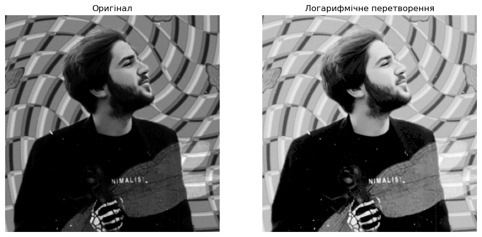

```python
import cv2 as cv
import numpy as np
import matplotlib.pyplot as plt

image_path = 'src/photo.png'

image_gray = cv.imread(image_path, cv.IMREAD_GRAYSCALE)

if image_gray is None:
    print(f"Помилка:{image_path}")
else:
    c = 255 / np.log(1 + 255)

    log_image = c * np.log1p(image_gray.astype(np.float64))

    image_log = np.array(log_image, dtype=np.uint8)

    plt.figure(figsize=(12, 6))

    plt.subplot(1, 2, 1)
    plt.imshow(image_gray, cmap='gray')
    plt.title("Оригінал")
    plt.axis('off')

    plt.subplot(1, 2, 2)
    plt.imshow(image_log, cmap='gray')
    plt.title(r'Логарифмічне перетворення')
    plt.axis('off')
    plt.show()
```

[3. Степенева(гамма-корекція)](https://docs.opencv.org/3.4/d3/dc1/tutorial_basic_linear_transform.html) s = c * r^gamma

[figure not shown]

```python
import cv2 as cv
import numpy as np
import matplotlib.pyplot as plt

image_path = 'src/photo.png'

image_gray = cv.imread(image_path, cv.IMREAD_GRAYSCALE)

if image_gray is None:
    print(f"Нема зображення! {image_path}")
else:
    gamma = 0.01

    image_norm = image_gray.astype(np.float64) / 255.0
    image_gamma_corrected = np.power(image_norm, gamma)
    image_gamma = np.array(image_gamma_corrected * 255, dtype=np.uint8)
    plt.figure(figsize=(12, 6))

    plt.subplot(1, 2, 1)
    plt.imshow(image_gray, cmap='gray')
    plt.title("Оригінал")
    plt.axis('off')

    plt.subplot(1, 2, 2)
    plt.imshow(image_gamma, cmap='gray')
    plt.title(rf'Гамма-корекція')
    plt.axis('off')
    plt.show()
```

[4. Соляризація зображення](https://msameeruddin.hashnode.dev/solarizing-the-image-with-numpy)

Формула градаційного перетворення для соляризації яка визначається порогом T:

$$ s = \begin{cases} r & \text{якщо } r < T \\ (L - 1) - r & \text{якщо } r \ge T \end{cases} $$

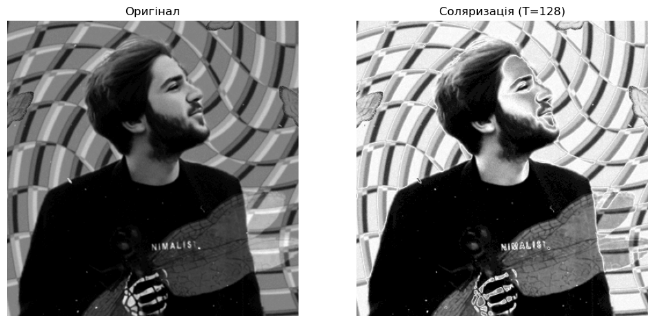

```python
import cv2 as cv
import numpy as np
import matplotlib.pyplot as plt
image_path = 'src/photo.png'
image_gray = cv.imread(image_path, cv.IMREAD_GRAYSCALE)

if image_gray is None:
    print(f"Помилка: Нема зображення {image_path}")
else:
    T = 128
    image_solarized = image_gray.copy()
    high_pixels_mask = (image_gray >= T)
    image_solarized[high_pixels_mask] = 255 - image_solarized[high_pixels_mask]
    plt.figure(figsize=(12, 6))

    plt.subplot(1, 2, 1)
    plt.imshow(image_gray, cmap='gray')
    plt.title("Оригінал")
    plt.axis('off')

    plt.subplot(1, 2, 2)
    plt.imshow(image_solarized, cmap='gray')
    plt.title(f'Соляризація (T={T})')
    plt.axis('off')
    plt.show()
```

**Відозміна гістограми**

[5. Еквалізація гістограми 1](https://habr.com/ru/articles/244507/)

І ще приклад [тут](https://docs.opencv.org/4.x/d5/daf/tutorial_py_histogram_equalization.html)

Еквалізація (вирівнювання) гістограми — це алгоритм, що автоматично підвищує глобальний контраст зображення. Метод базується на аналізі гістограми, тобто розподілу пікселів за рівнями яскравості (від 0 до 255). Головна ідея полягає у трансформації початкового розподілу яскравостей до більш рівномірного стану. Це реалізується шляхом "розтягування" найчастіших діапазонів яскравості та "стискання" рідкісних. Як наслідок, деталі стають чіткішими: темні ділянки стають глибшими, а світлі — яскравішими. Цей підхід є найбільш ефективним для зображень із низьким контрастом, а також для надто темних чи засвічених фото.

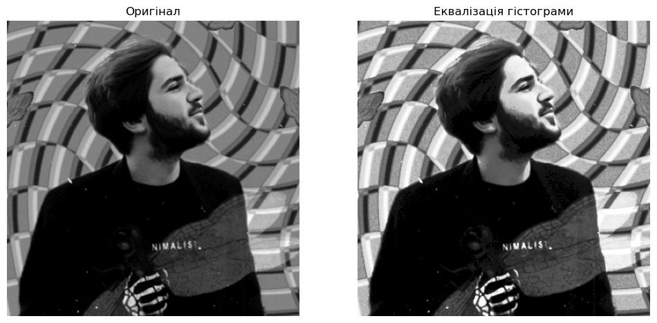

```python
import cv2 as cv
import numpy as np
import matplotlib.pyplot as plt

image_path = 'src/photo.png'
image_gray = cv.imread(image_path, cv.IMREAD_GRAYSCALE)
if image_gray is None:
    print(f"Нема {image_path}")
else:
    image_equalized = cv.equalizeHist(image_gray)
    plt.figure(figsize=(12, 6))
    plt.subplot(1, 2, 1)
    plt.imshow(image_gray, cmap='gray')
    plt.title("Оригінал")
    plt.axis('off')
    plt.subplot(1, 2, 2)
    plt.imshow(image_equalized, cmap='gray')
    plt.title('Еквалізація гістограми')
    plt.axis('off')
    plt.show()
```

[6. Оцінка гістограми](https://docs.opencv.org/4.x/d6/dc7/group__imgproc__hist.html#ga6ca1876785483836f72a77ced8ea759a)  
[Ще одне посилання](https://docs.opencv.org/4.x/d8/dbc/tutorial_histogram_calculation.html)

Аналіз гістограми — це вивчення графічного розподілу, який показує, як часто зустрічаються пікселі з різними рівнями яскравості (від 0 до 255). Він дає змогу швидко визначити характеристики зображення: чи є воно надто темним, пересвітленим або малоконтрастним. Окрім цього, гістограма допомагає підібрати оптимальний поріг для бінаризації. Якщо розподіл має два виражені піки (бімодальний характер: окремо для фону та об’єкта), то оптимальне порогове значення розташоване в «долині» — точці мінімуму між цими піками.

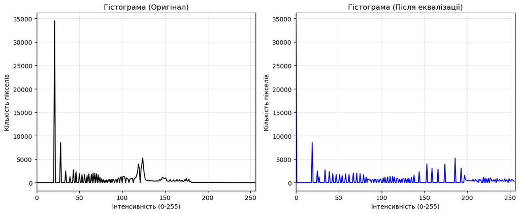

```python
import cv2 as cv
import numpy as np
import matplotlib.pyplot as plt

image_path = 'src/photo.png'
image_gray = cv.imread(image_path, cv.IMREAD_GRAYSCALE)

if image_gray is None:
    print(f"Нема{image_path}")
else:
    hist_original = cv.calcHist([image_gray], [0], None, [256], [0, 256])
    image_equalized = cv.equalizeHist(image_gray)
    hist_equalized = cv.calcHist([image_equalized], [0], None, [256], [0, 256])

    plt.figure(figsize=(12, 5))

    # Лівий графік
    plt.subplot(1, 2, 1)
    plt.plot(hist_original, color='black')
    plt.title('Гістограма (Оригінал)')
    plt.xlabel('Інтенсивність (0-255)')
    plt.ylabel('Кількість пікселів')
    plt.xlim([0, 256])
    plt.grid(True, alpha=0.3)

    # Правий графік
    plt.subplot(1, 2, 2)
    plt.plot(hist_equalized, color='blue')
    plt.title('Гістограма (Після еквалізації)')
    plt.xlabel('Інтенсивність (0-255)')
    plt.ylabel('Кількість пікселів')
    plt.xlim([0, 256])
    plt.grid(True, alpha=0.3)

    plt.tight_layout()
    plt.show()
```

**Контрольні запитання**

1. У чому полягає сенс градаційних перетворень?

Градаційні перетворення полягають у зміні зображення шляхом перерахунку значень інтенсивності (яскравості) окремих пікселів.  
Ці підходи відносяться до точкових операцій, де розмір вікна становить 1×1. Тобто значення яскравості пікселя на виході ($s$) залежить лише від його початкового значення ($r$) та визначається заданою функцією перетворення:

$$ s = T(r) $$

2. На чому ґрунтуються гістограмні методи?

Гістограмні методи базуються на статистичному аналізі загального розподілу яскравостей пікселів у всьому зображенні.  
На відміну від градаційних перетворень, які обробляють кожен піксель окремо, ці методи використовують інформацію з гістограми — частотного графіка, що відображає кількість пікселів для кожного рівня інтенсивності в діапазоні 0–255.  
Отримані глобальні статистичні дані застосовуються для покращення зображення, зокрема для:

Еквалізації гістограми — розширення динамічного діапазону яскравостей з метою підвищення загального контрасту.

Аналізу гістограми — знаходження оптимальних порогових значень, наприклад, у задачах бінаризації.